# atividade de econometria regresão multipla

joseferson da silva barreto

13/12/2021

# Objetivo

Objetivo é realizar uma regressão multípla afim de verificar se existe relação entre o nível de CO2 com o número da população e o PIB, ou seja , verificar se quanto maior a população e seu Pib , maior a emissão de CO2 n atmosfera. Neste caso , iremos utilizar um banco de dados fictício disponibilizado na aula passada **06/12/2021**.

# Chamando o banco de dados

```r
dados<-read.csv("C:/Users/josef/Documents/econometria2.csv",sep = ";",header = T)

str(dados)
```

```
## 'data.frame':    8 obs. of  3 variables:
##  $ ï..pop: num  3.2 35.5 19.1 40.4 3.1 22.3 8.4 9
##  $ co2   : num  1.5 8.7 2.8 9.4 4.4 8.4 3.2 0.9
##  $ pib   : num  13.2 197 128.6 286.4 72.6 ...
```

# Criando o modelo

```r
mod<- lm(lm(co2 ~ pib+pop, dados))

mod
```

```
##
## Call:
## lm(formula = lm(co2 ~ pib + pop, dados))
##
## Coefficients:
## (Intercept)          pib          pop
##     0.47234      0.03048      0.02757
```

```r
summary(mod)
```

```
##
## Call:
## lm(formula = lm(co2 ~ pib + pop, dados))
##
## Residuals:
##       1       2       3       4       5       6       7       8
##  0.5372  1.2452 -2.1181 -0.9145  1.6297  2.1990 -0.9903 -1.5881
##
## Coefficients:
##             Estimate Std. Error t value Pr(>|t|)
## (Intercept)  0.47234    1.32844   0.356    0.737
## pib          0.03048    0.02486   1.226    0.275
## pop          0.02757    0.15044   0.183    0.862
##
## Residual standard error: 1.906 on 5 degrees of freedom
## Multiple R-squared:  0.7787, Adjusted R-squared:  0.6902
## F-statistic: 8.798 on 2 and 5 DF,  p-value: 0.02303
```

Como os valores do Pvalor teste T foi maior que 0,05 temos os Betas estimados são estatisticamente iguais a zero, ou seja , temos a presença de multicolinearidade

## observando a multicolinearidade

Vamos observar a multicolinariedade existente , já que o pprimeiro pressuposto não foi atendido

[output not shown]

```r
library(gt)
library(DT)

rho <- cor(dados, method = "spearman")

#cortest.bartlett(rho, n = nrow(dados))

rho %>% datatable()
```

|  | pop | co2 | pib |
| --- | --- | --- | --- |
| pop | 1 | 0.642857142857143 | 0.880952380952381 |
| co2 | 0.642857142857143 | 1 | 0.880952380952381 |
| pib | 0.880952380952381 | 0.880952380952381 | 1 |

Como podemos observar pela tabela temos uma correlação forte e positiva entre as variavéis , isso acaba prejudicando o modelo já que essa auto correlação acaba prejudicado a explicação do modelo em relação a variavél dependente .

## plotando o gráfico de correlação

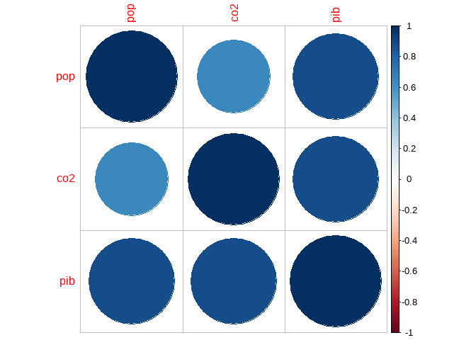

```r
rho <- cor(dados, method = "spearman")

#cortest.bartlett(rho, n = nrow(dados))


corrplot(rho)
```

## outro gráfico

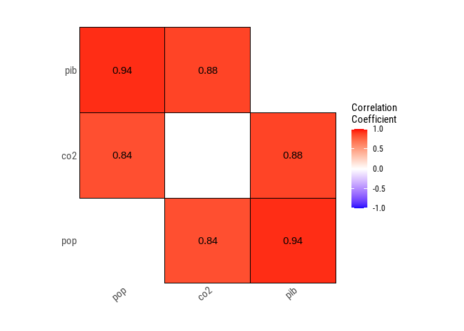

```r
# Correlação das variáveis numéricas
#correlate(dados)
plot_correlate(dados)
```

perceba que o nível de correlação entre as variavéis é muito alto

# Conclusão

Como o modelo não atendeu o primeiro pressuposto em relação ao teste t as variáveis individualmente não são significativas, logo, concluimosque existe multicolinearidade e executamos a matriz de correlação para verificar se de fato existia correlação .

```r
y<-co2/pop
x<-pib/pop

k<-summary(lm(y~x))

k
```

```
##
## Call:
## lm(formula = y ~ x)
##
## Residuals:
##      Min       1Q   Median       3Q      Max
## -0.29184 -0.13139 -0.00751  0.08843  0.35054
##
## Coefficients:
##             Estimate Std. Error t value Pr(>|t|)
## (Intercept) -0.12276    0.14373  -0.854  0.42584
## x            0.05841    0.01302   4.488  0.00416 **
## ---
## Signif. codes:  0 '***' 0.001 '**' 0.01 '*' 0.05 '.' 0.1 ' ' 1
##
## Residual standard error: 0.2184 on 6 degrees of freedom
## Multiple R-squared:  0.7705, Adjusted R-squared:  0.7322
## F-statistic: 20.14 on 1 and 6 DF,  p-value: 0.004157
```

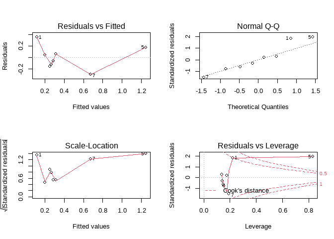

```r
y<-co2/pop
x<-pib/pop

k<-summary(lm(y~x))
par(mfrow=c(2,2))
plot(lm(y~x))
```